# Data Visualization and Google Trends

seymacakir

19.04.2021

**Overview of Data**

The data includes monthly export in thousands of dollars, exchange rate of USD, and USD reserve of Central Bank of Turkey in millionS of dollars from 2013 to 2020.

Example of Data

| DATE | EXPORT | USD | RESERVE |
| --- | --- | --- | --- |
| 2013-01-01 | 12263324 | 1.76 | 103550 |
| 2013-02-01 | 13155176 | 1.77 | 104437 |
| 2013-03-01 | 14066304 | 1.81 | 105650 |
| 2013-04-01 | 13450015 | 1.80 | 113269 |
| 2013-05-01 | 14141543 | 1.82 | 108773 |
| 2013-06-01 | 13053397 | 1.89 | 105566 |

# 1.EXPORT

There is the monthly export volume of Turkey in thousands of USD from 2013 to 2020.

## Plot of Export Volume in Turkey

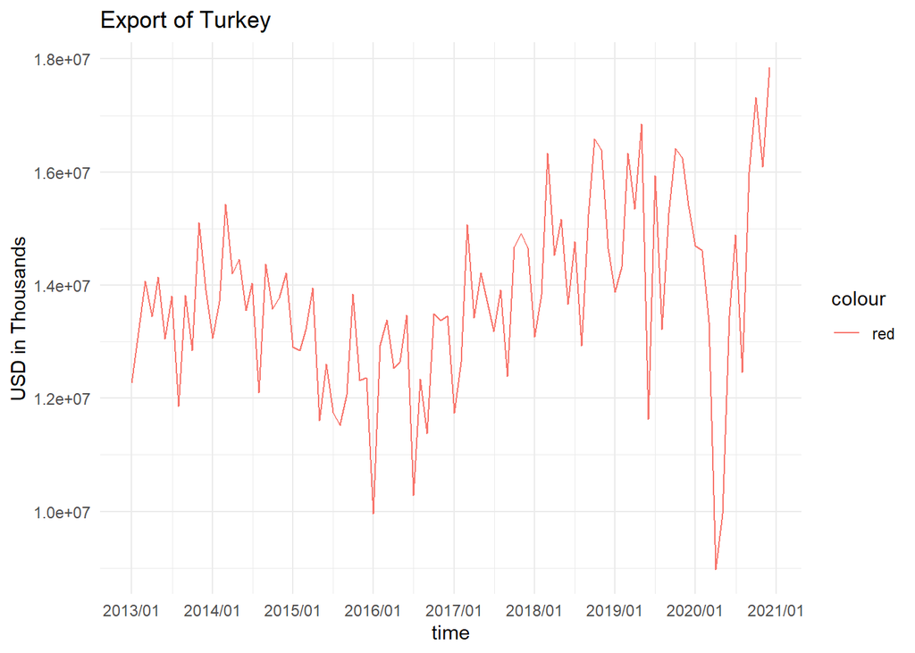

It can be observed that there are many fluctuations.However, the drop of volume in the beginnings of years and the pattern in during the years looks like a pattern. There would be callender effect and season effect in data. Besides, in 2020, there is a sharp drop which can be due to Covid-19 pandemic crises.

## Distrubtion of Export

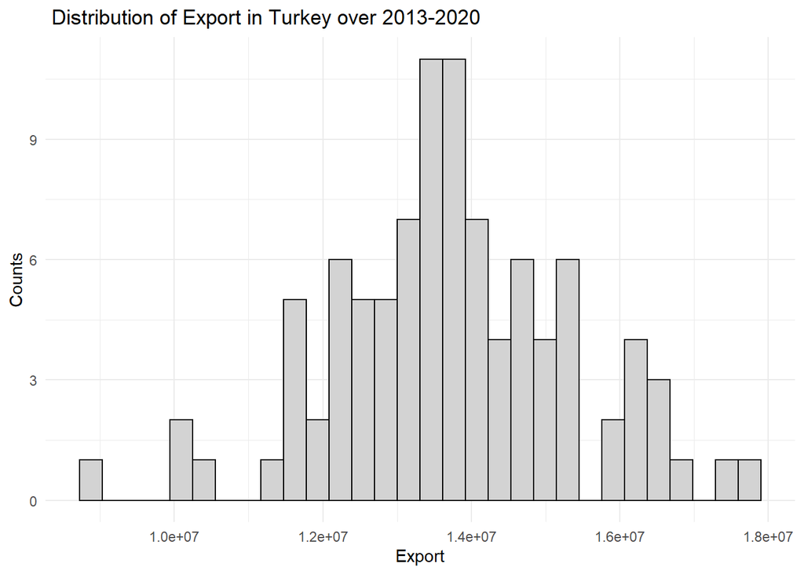

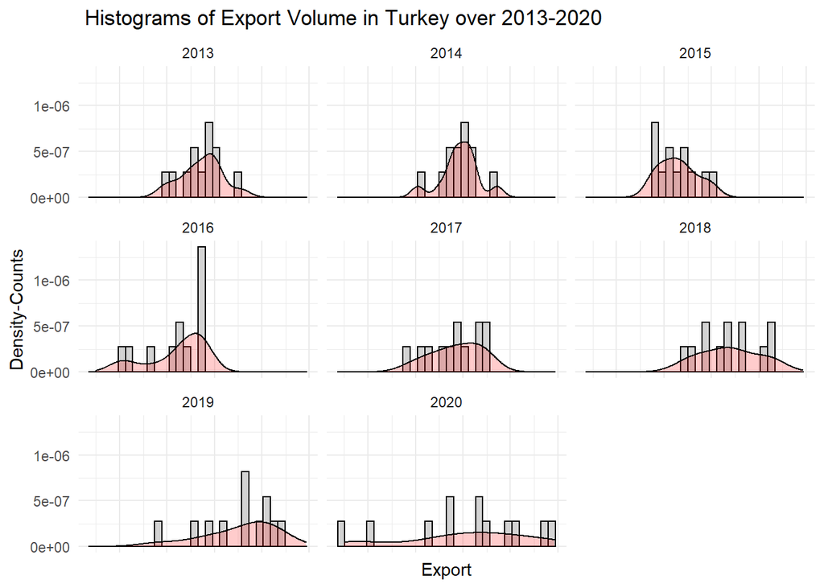

In overall, the distribution of volume export is close to normal distribution. However, It have get flattered and its bell shape has been deformed. By looking plot graph, we can say that the fluctuations caused the flatter shape of distribution by increasing deviation.  
## Boxplots of Export Volume

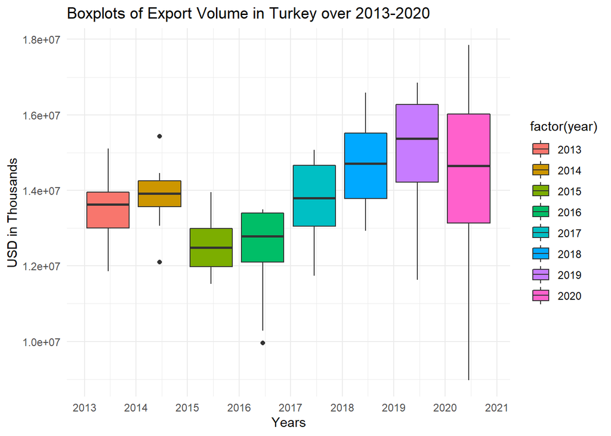

The boxplots show that after the 2016 average export volume increase until 2020 and the range of the data have increased.

## Trend: Hal Fiyatları

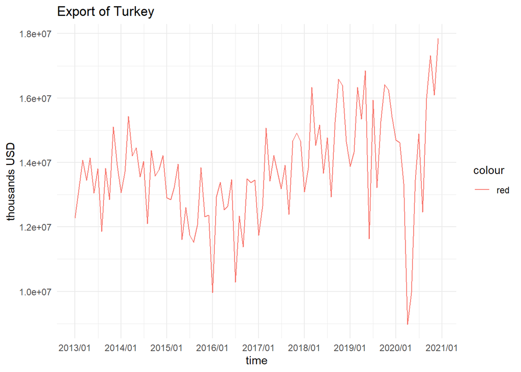

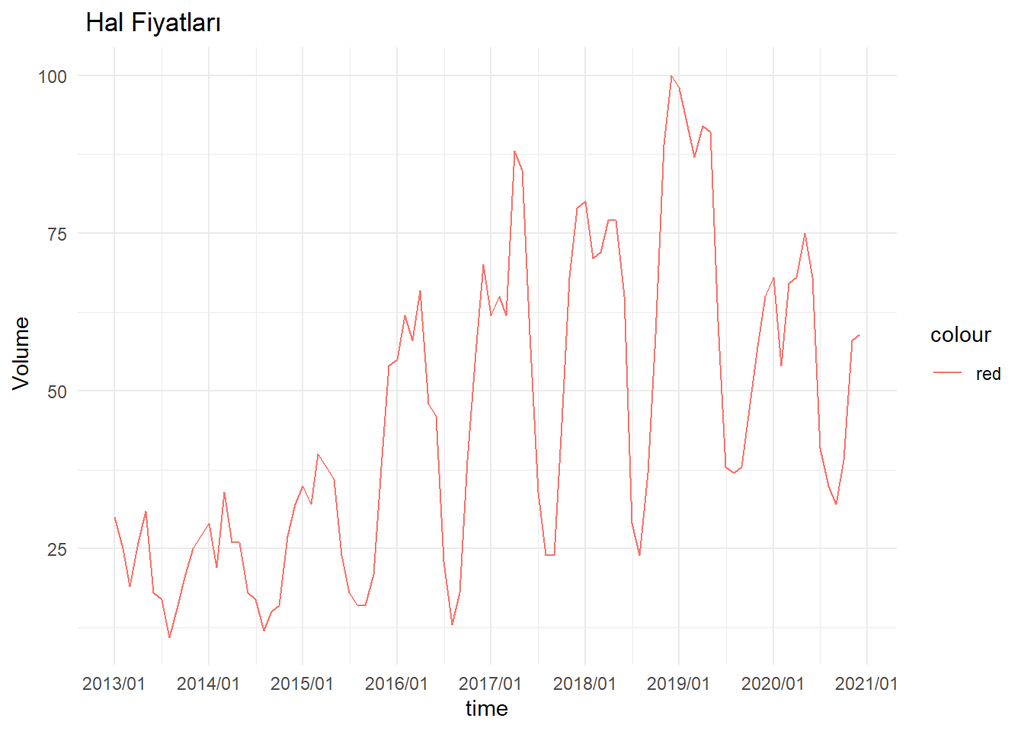

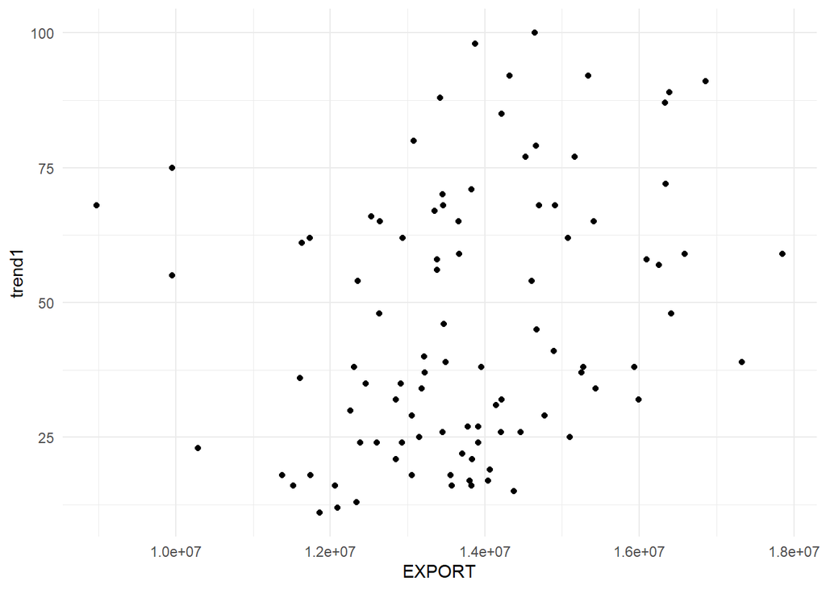

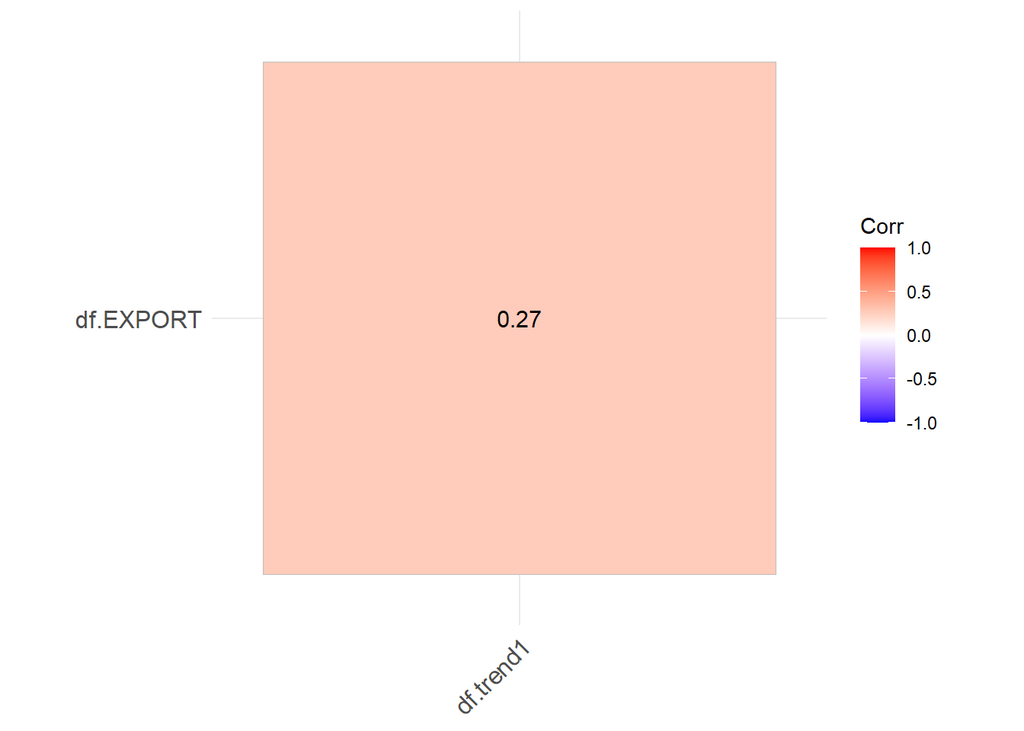

I have searched “Hal Fiyatları” as a key words in Google Trends because I think that export volume can affect the prices. However, the scatter plot does not show a significant trend and correlation is small for to be significant.

# 2. USD EXCHANGE RATE

There is the monthly USD exchange rate in Turkey from 2013 to 2020.

## Plot of USD Exchange Rate in Turkey

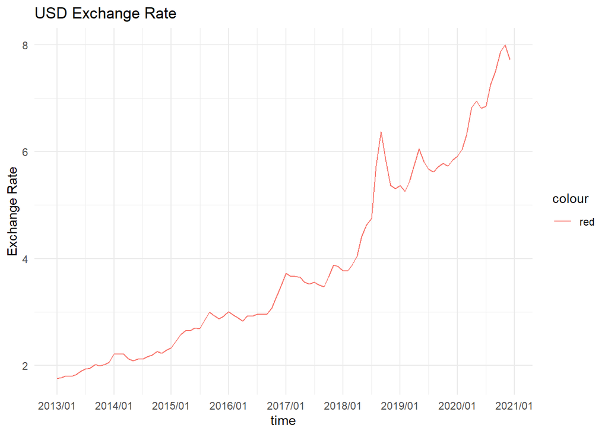

The plot of USD exchange rate shows a clear increasing trend during the time. ## Distribution of USD Exchange Rate

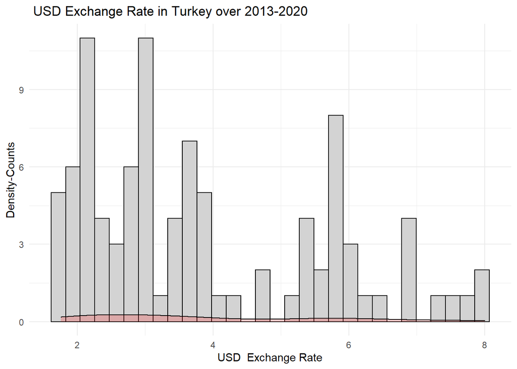

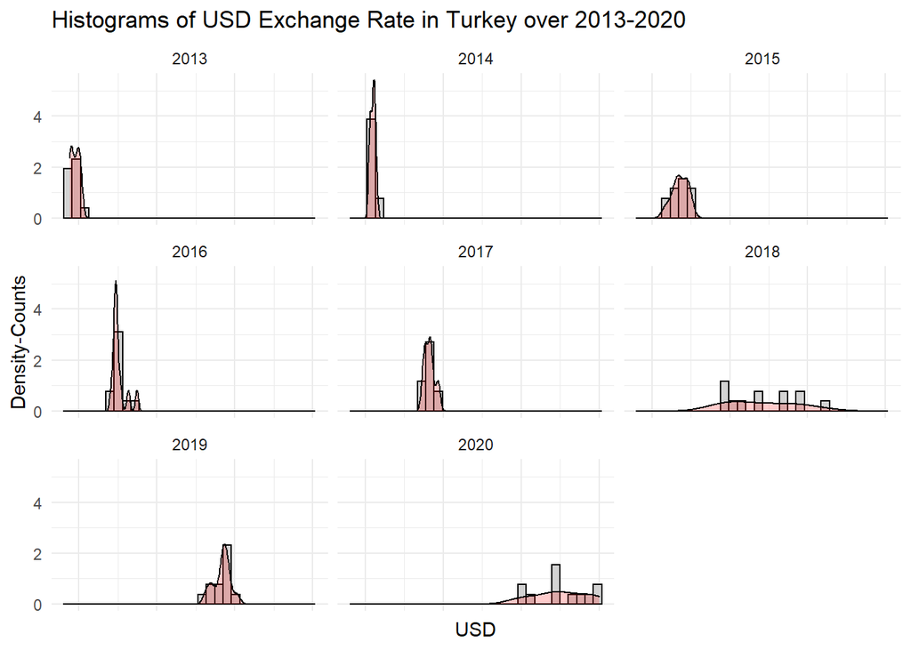

Since there is a increasing trend, the data does not show normal distribution, however, the mean of the data has shifted.

## Boxplots of USD Exchange Rate

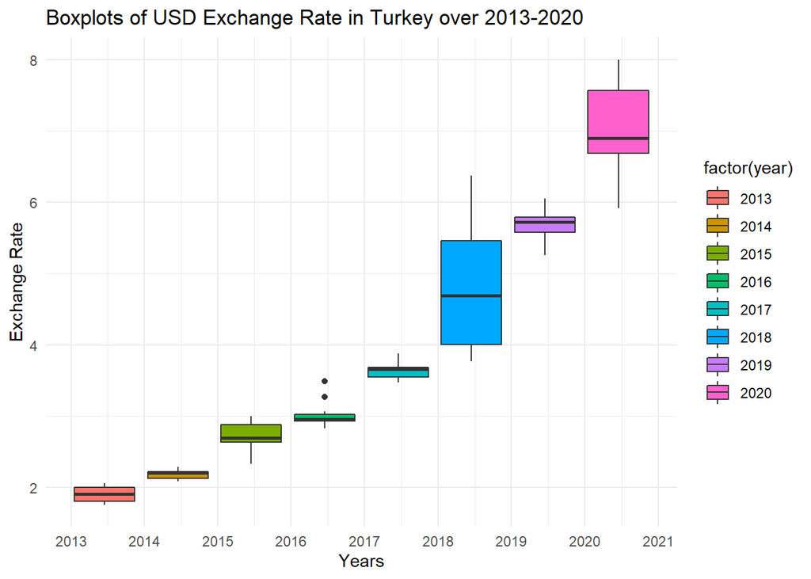

the Box plots show more clear the increase in average USD exchange rate. Moreover, the range shows us to compare increasing rate. In 2018, USD Exchange rates have increased sharply.

## Trend : Bilgisayar Fiyatları

[figure not shown]

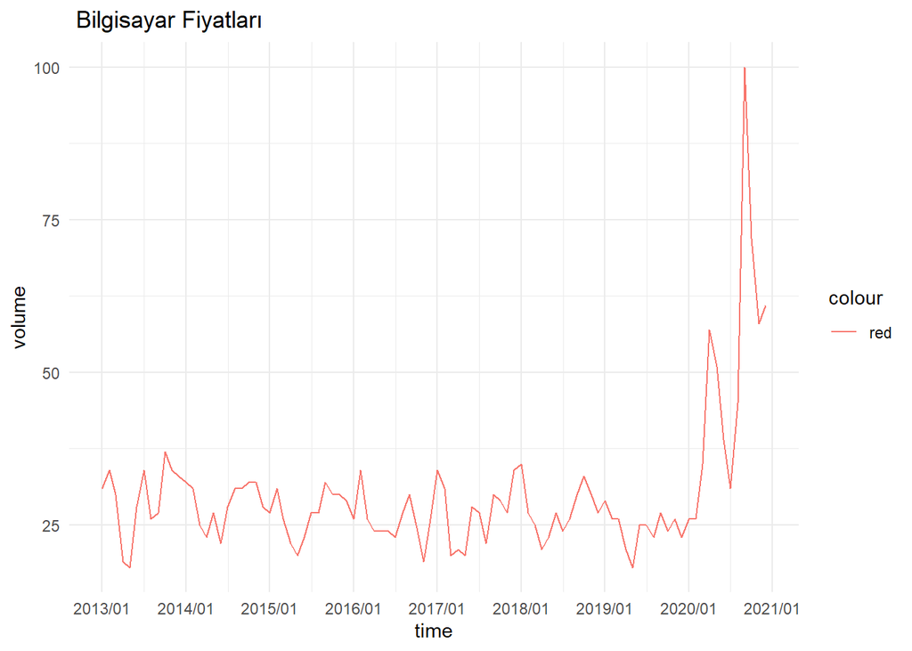

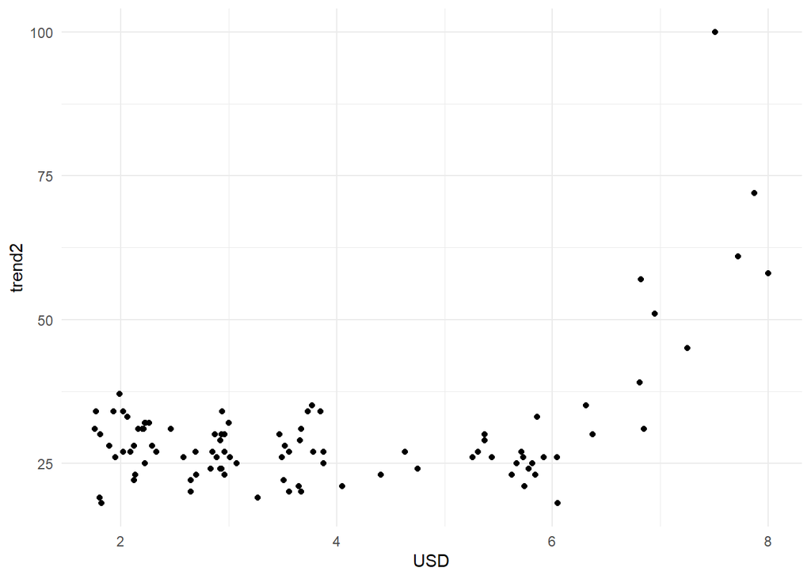

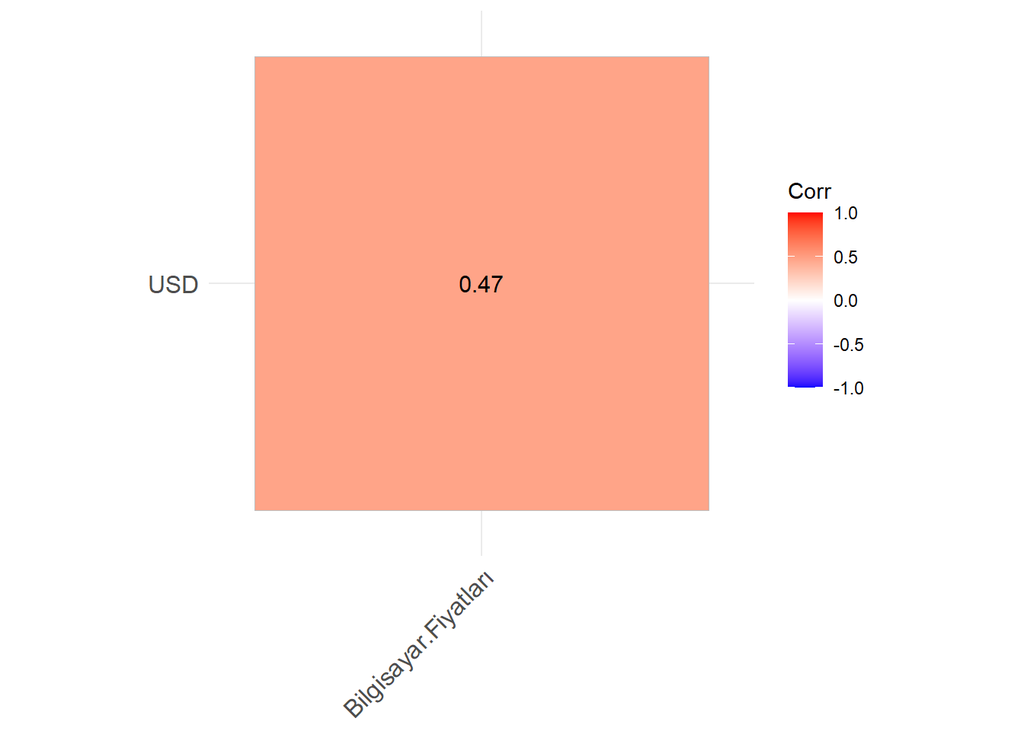

I have searched “Bilgisayar Fiyatları” as a key words in Google Trends because I think that exchange rates can affect the computer prices prices since we import computers.Therefore, people will search for decreasing in prices.Although correlation is small for to be significant, the scatter plot shows people have searched more when exchange rate increased.

# 3. RESERVE

There is the monthly USD Reserves of Central Bank of Turkey from 2013 to 2020.

## Plot of USD Reserve of Central Bank in Turkey

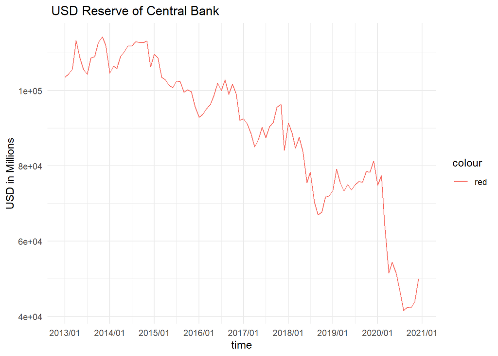

We observe that there is a decreasing trend in USD Reserves of Turkey Central Bank.

## Distribution of USD Reserves

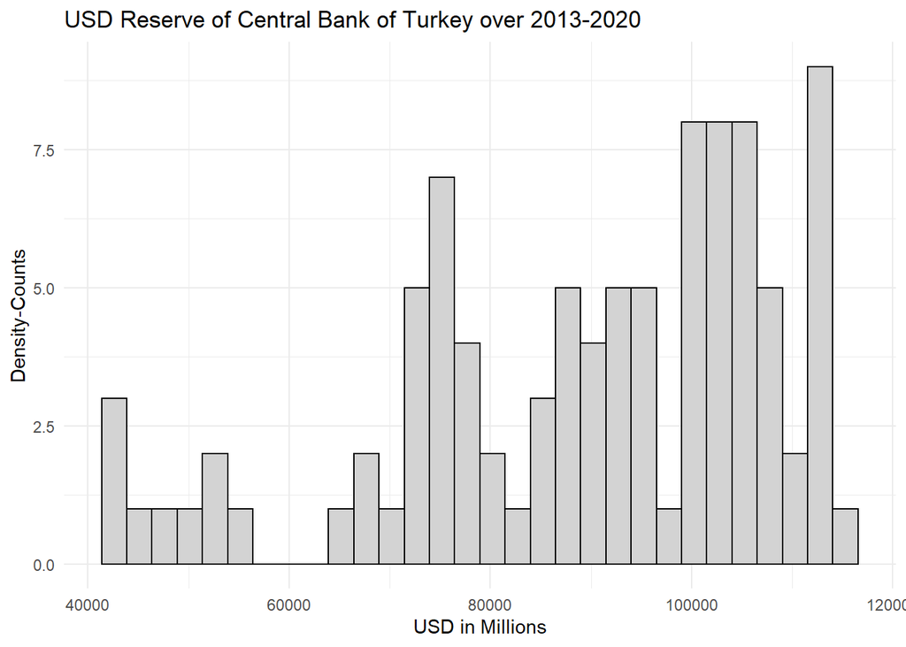

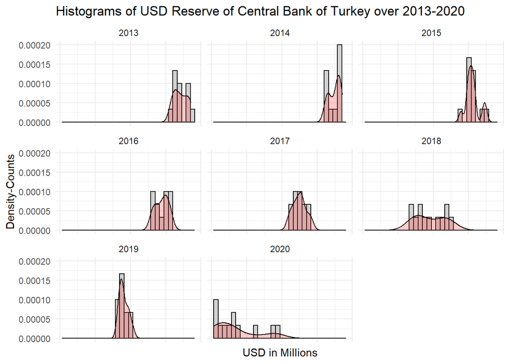

By looking the histograms, we can say that even if there is a decresing the USD Reserves in a year does not change very quickly.

## Boxplots of USD Reserves

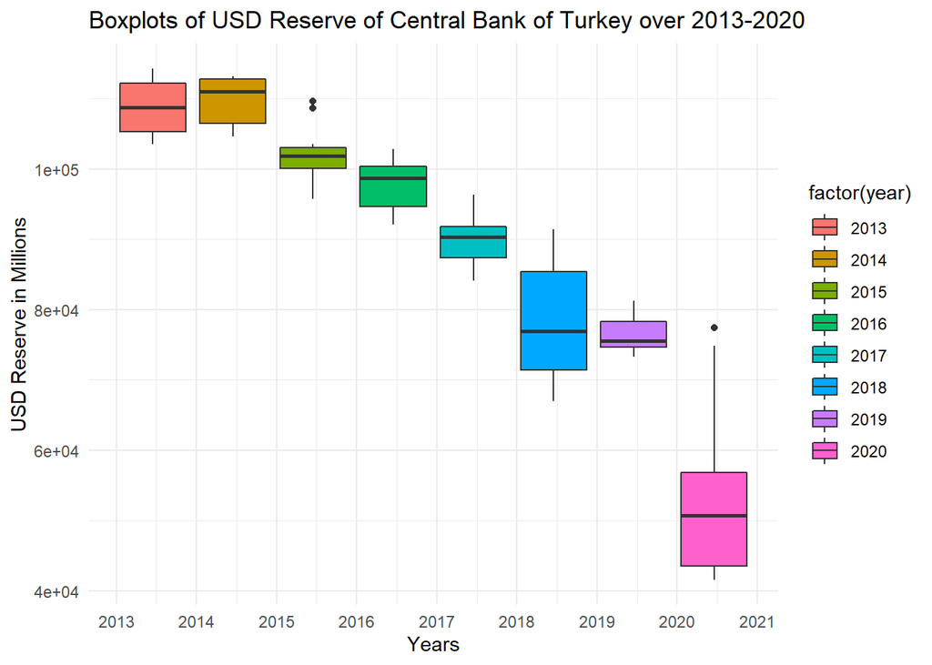

The Boxplots shows that there is a clear decrease in the average USD reserves of Central Bank

## Trend : “Ekonomik Kriz”

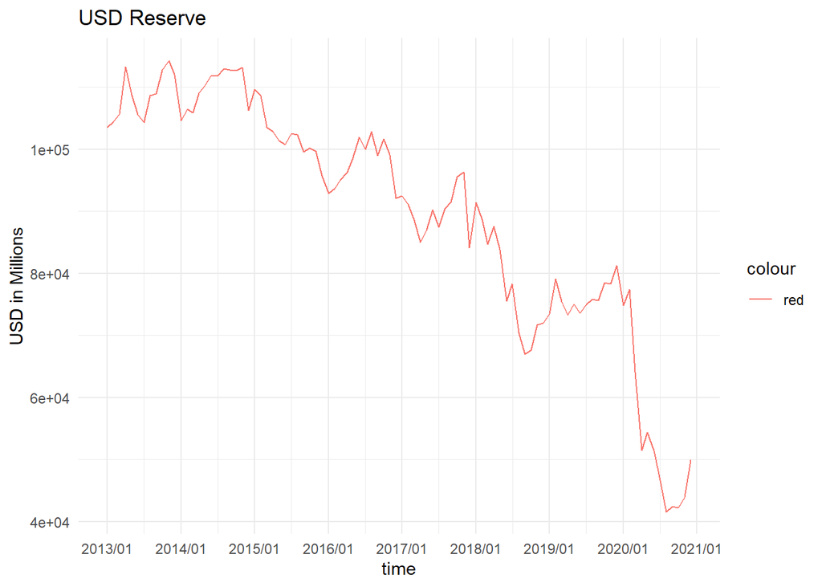

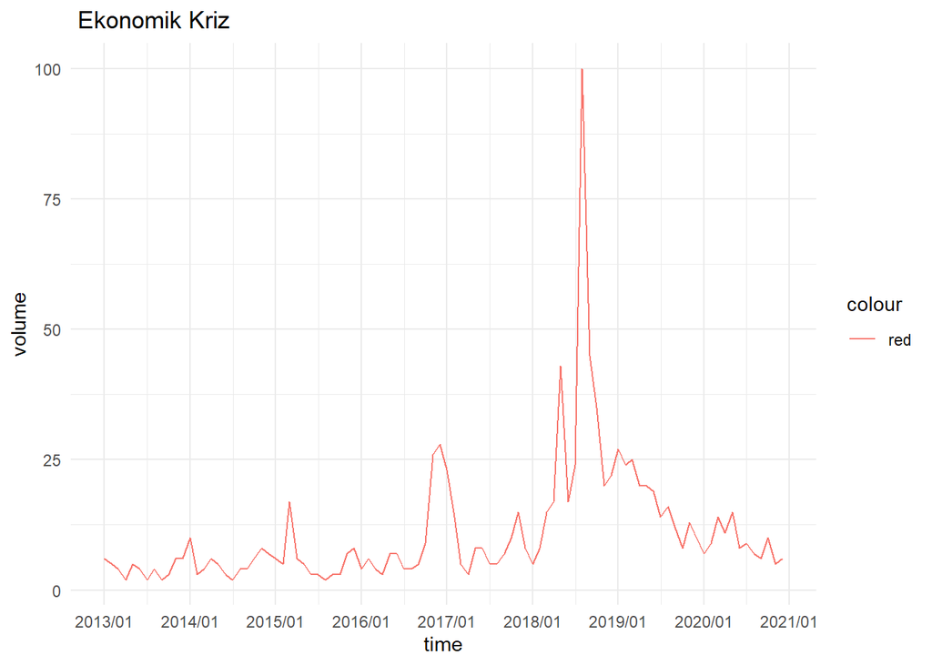

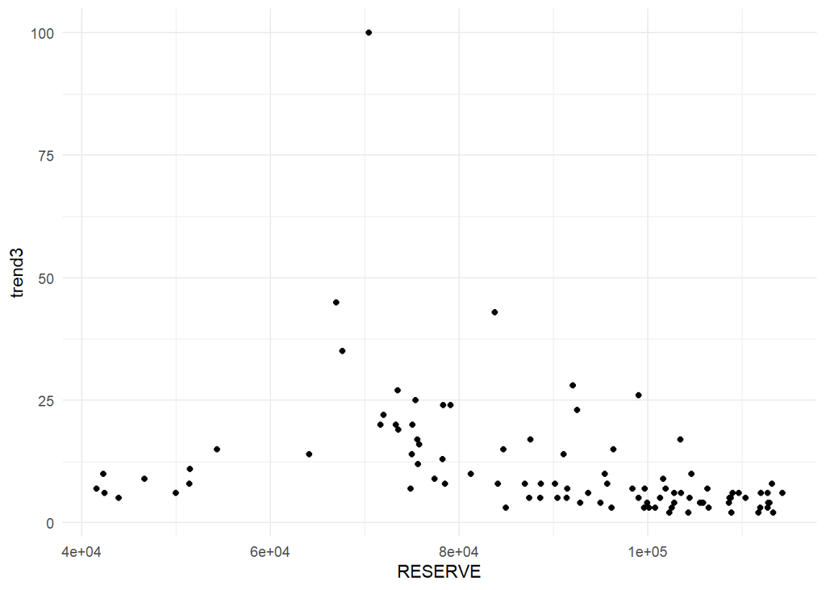

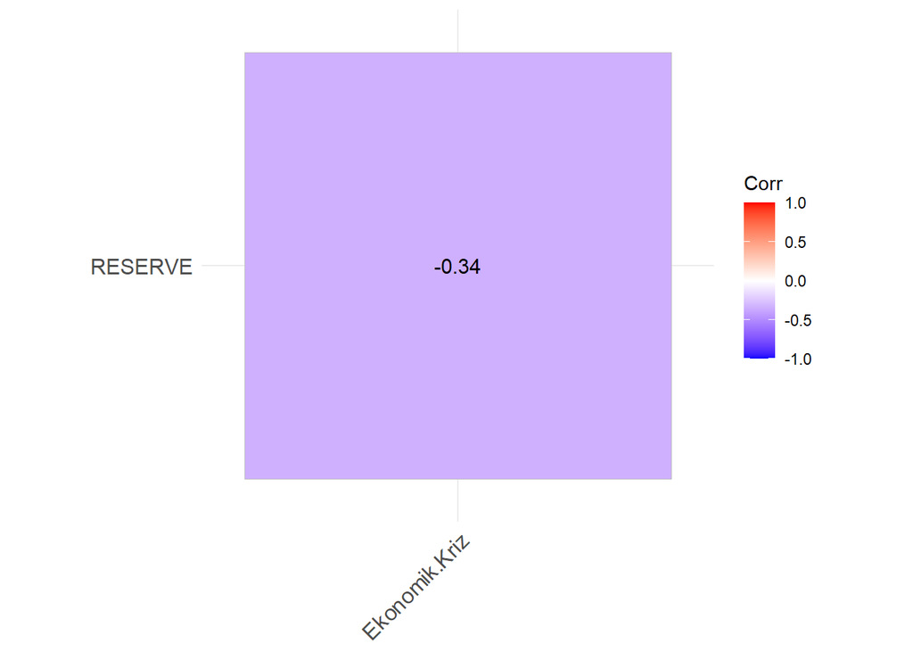

I have searched “Ekonomik Kriz” as a key words in Google Trends because I think that economic crises affect the montary policy of Central Bank. Therefore, people will search for decreasing in prices. In 2018, there is a sharp decrease in USD reserves and peak for google trend. We can say that it is possible to there is an economic crise in 2018.

# RMD [here](https://bu-ie-360.github.io/spring21-seymacakir/files/homework-1/homework-1.Rmd)